# Risk Factor Analysis

## Outcome Variable

**Outcome Variable:** y_rate_len

## Predictor Variables

**Intervention Variable:** nhh

**Adjustment Set:**

- arm
- W_mage
- meducyrs
- feducyrs
- W_mhtcm
- W_mwtkg
- W_mbmi
- W_nrooms
- trth2o
- cleanck
- impfloor
- impsan
- safeh20
- delta_W_mage
- delta_meducyrs
- delta_feducyrs
- delta_W_mhtcm
- delta_W_mwtkg
- delta_W_mbmi
- delta_W_nrooms
- delta_trth2o
- delta_cleanck
- delta_impfloor
- delta_impsan
- delta_safeh20

## Stratifying Variables

The analysis was stratified on these variable(s):

- agecat
- studyid
- country

## Data Summary

| agecat | studyid | country | nhh | n_cell | n |
| --- | --- | --- | --- | --- | --- |
| 0-3 months | ki1000108-IRC | INDIA | 3 or less | 53 | 377 |
| 0-3 months | ki1000108-IRC | INDIA | 4-5 | 146 | 377 |
| 0-3 months | ki1000108-IRC | INDIA | 6-7 | 99 | 377 |
| 0-3 months | ki1000108-IRC | INDIA | 8+ | 79 | 377 |
| 0-3 months | ki1017093-NIH-Birth | BANGLADESH | 3 or less | 101 | 566 |
| 0-3 months | ki1017093-NIH-Birth | BANGLADESH | 4-5 | 239 | 566 |
| 0-3 months | ki1017093-NIH-Birth | BANGLADESH | 6-7 | 132 | 566 |
| 0-3 months | ki1017093-NIH-Birth | BANGLADESH | 8+ | 94 | 566 |
| 0-3 months | ki1017093b-PROVIDE | BANGLADESH | 3 or less | 123 | 634 |
| 0-3 months | ki1017093b-PROVIDE | BANGLADESH | 4-5 | 291 | 634 |
| 0-3 months | ki1017093b-PROVIDE | BANGLADESH | 6-7 | 135 | 634 |
| 0-3 months | ki1017093b-PROVIDE | BANGLADESH | 8+ | 85 | 634 |
| 0-3 months | ki1017093c-NIH-Crypto | BANGLADESH | 3 or less | 107 | 720 |
| 0-3 months | ki1017093c-NIH-Crypto | BANGLADESH | 4-5 | 324 | 720 |
| 0-3 months | ki1017093c-NIH-Crypto | BANGLADESH | 6-7 | 169 | 720 |
| 0-3 months | ki1017093c-NIH-Crypto | BANGLADESH | 8+ | 120 | 720 |
| 3-6 months | ki1000108-IRC | INDIA | 3 or less | 57 | 397 |
| 3-6 months | ki1000108-IRC | INDIA | 4-5 | 154 | 397 |
| 3-6 months | ki1000108-IRC | INDIA | 6-7 | 103 | 397 |
| 3-6 months | ki1000108-IRC | INDIA | 8+ | 83 | 397 |
| 3-6 months | ki1017093-NIH-Birth | BANGLADESH | 3 or less | 89 | 523 |
| 3-6 months | ki1017093-NIH-Birth | BANGLADESH | 4-5 | 223 | 523 |
| 3-6 months | ki1017093-NIH-Birth | BANGLADESH | 6-7 | 126 | 523 |
| 3-6 months | ki1017093-NIH-Birth | BANGLADESH | 8+ | 85 | 523 |
| 3-6 months | ki1017093b-PROVIDE | BANGLADESH | 3 or less | 102 | 574 |
| 3-6 months | ki1017093b-PROVIDE | BANGLADESH | 4-5 | 270 | 574 |
| 3-6 months | ki1017093b-PROVIDE | BANGLADESH | 6-7 | 124 | 574 |
| 3-6 months | ki1017093b-PROVIDE | BANGLADESH | 8+ | 78 | 574 |
| 3-6 months | ki1017093c-NIH-Crypto | BANGLADESH | 3 or less | 101 | 695 |
| 3-6 months | ki1017093c-NIH-Crypto | BANGLADESH | 4-5 | 316 | 695 |
| 3-6 months | ki1017093c-NIH-Crypto | BANGLADESH | 6-7 | 163 | 695 |
| 3-6 months | ki1017093c-NIH-Crypto | BANGLADESH | 8+ | 115 | 695 |
| 6-12 months | ki1000108-IRC | INDIA | 3 or less | 57 | 400 |
| 6-12 months | ki1000108-IRC | INDIA | 4-5 | 154 | 400 |
| 6-12 months | ki1000108-IRC | INDIA | 6-7 | 104 | 400 |
| 6-12 months | ki1000108-IRC | INDIA | 8+ | 85 | 400 |
| 6-12 months | ki1000304b-SAS-FoodSuppl | INDIA | 3 or less | 26 | 332 |
| 6-12 months | ki1000304b-SAS-FoodSuppl | INDIA | 4-5 | 146 | 332 |
| 6-12 months | ki1000304b-SAS-FoodSuppl | INDIA | 6-7 | 106 | 332 |
| 6-12 months | ki1000304b-SAS-FoodSuppl | INDIA | 8+ | 54 | 332 |
| 6-12 months | ki1017093-NIH-Birth | BANGLADESH | 3 or less | 87 | 482 |
| 6-12 months | ki1017093-NIH-Birth | BANGLADESH | 4-5 | 202 | 482 |
| 6-12 months | ki1017093-NIH-Birth | BANGLADESH | 6-7 | 112 | 482 |
| 6-12 months | ki1017093-NIH-Birth | BANGLADESH | 8+ | 81 | 482 |
| 6-12 months | ki1017093b-PROVIDE | BANGLADESH | 3 or less | 97 | 545 |
| 6-12 months | ki1017093b-PROVIDE | BANGLADESH | 4-5 | 258 | 545 |
| 6-12 months | ki1017093b-PROVIDE | BANGLADESH | 6-7 | 114 | 545 |
| 6-12 months | ki1017093b-PROVIDE | BANGLADESH | 8+ | 76 | 545 |
| 6-12 months | ki1017093c-NIH-Crypto | BANGLADESH | 3 or less | 95 | 676 |
| 6-12 months | ki1017093c-NIH-Crypto | BANGLADESH | 4-5 | 307 | 676 |
| 6-12 months | ki1017093c-NIH-Crypto | BANGLADESH | 6-7 | 164 | 676 |
| 6-12 months | ki1017093c-NIH-Crypto | BANGLADESH | 8+ | 110 | 676 |
| 6-12 months | ki1148112-LCNI-5 | MALAWI | 3 or less | 119 | 430 |
| 6-12 months | ki1148112-LCNI-5 | MALAWI | 4-5 | 183 | 430 |
| 6-12 months | ki1148112-LCNI-5 | MALAWI | 6-7 | 95 | 430 |
| 6-12 months | ki1148112-LCNI-5 | MALAWI | 8+ | 33 | 430 |
| 12-24 months | ki1000108-IRC | INDIA | 3 or less | 57 | 396 |
| 12-24 months | ki1000108-IRC | INDIA | 4-5 | 151 | 396 |
| 12-24 months | ki1000108-IRC | INDIA | 6-7 | 103 | 396 |
| 12-24 months | ki1000108-IRC | INDIA | 8+ | 85 | 396 |
| 12-24 months | ki1017093-NIH-Birth | BANGLADESH | 3 or less | 74 | 421 |
| 12-24 months | ki1017093-NIH-Birth | BANGLADESH | 4-5 | 181 | 421 |
| 12-24 months | ki1017093-NIH-Birth | BANGLADESH | 6-7 | 97 | 421 |
| 12-24 months | ki1017093-NIH-Birth | BANGLADESH | 8+ | 69 | 421 |
| 12-24 months | ki1017093b-PROVIDE | BANGLADESH | 3 or less | 86 | 458 |
| 12-24 months | ki1017093b-PROVIDE | BANGLADESH | 4-5 | 213 | 458 |
| 12-24 months | ki1017093b-PROVIDE | BANGLADESH | 6-7 | 96 | 458 |
| 12-24 months | ki1017093b-PROVIDE | BANGLADESH | 8+ | 63 | 458 |
| 12-24 months | ki1017093c-NIH-Crypto | BANGLADESH | 3 or less | 68 | 495 |
| 12-24 months | ki1017093c-NIH-Crypto | BANGLADESH | 4-5 | 224 | 495 |
| 12-24 months | ki1017093c-NIH-Crypto | BANGLADESH | 6-7 | 125 | 495 |
| 12-24 months | ki1017093c-NIH-Crypto | BANGLADESH | 8+ | 78 | 495 |
| 12-24 months | ki1148112-LCNI-5 | MALAWI | 3 or less | 89 | 307 |
| 12-24 months | ki1148112-LCNI-5 | MALAWI | 4-5 | 130 | 307 |
| 12-24 months | ki1148112-LCNI-5 | MALAWI | 6-7 | 64 | 307 |
| 12-24 months | ki1148112-LCNI-5 | MALAWI | 8+ | 24 | 307 |

The following strata were considered:

- agecat: 0-3 months, studyid: ki1000108-IRC, country: INDIA
- agecat: 0-3 months, studyid: ki1017093-NIH-Birth, country: BANGLADESH
- agecat: 0-3 months, studyid: ki1017093b-PROVIDE, country: BANGLADESH
- agecat: 0-3 months, studyid: ki1017093c-NIH-Crypto, country: BANGLADESH
- agecat: 12-24 months, studyid: ki1000108-IRC, country: INDIA
- agecat: 12-24 months, studyid: ki1017093-NIH-Birth, country: BANGLADESH
- agecat: 12-24 months, studyid: ki1017093b-PROVIDE, country: BANGLADESH
- agecat: 12-24 months, studyid: ki1017093c-NIH-Crypto, country: BANGLADESH
- agecat: 12-24 months, studyid: ki1148112-LCNI-5, country: MALAWI
- agecat: 3-6 months, studyid: ki1000108-IRC, country: INDIA
- agecat: 3-6 months, studyid: ki1017093-NIH-Birth, country: BANGLADESH
- agecat: 3-6 months, studyid: ki1017093b-PROVIDE, country: BANGLADESH
- agecat: 3-6 months, studyid: ki1017093c-NIH-Crypto, country: BANGLADESH
- agecat: 6-12 months, studyid: ki1000108-IRC, country: INDIA
- agecat: 6-12 months, studyid: ki1000304b-SAS-FoodSuppl, country: INDIA
- agecat: 6-12 months, studyid: ki1017093-NIH-Birth, country: BANGLADESH
- agecat: 6-12 months, studyid: ki1017093b-PROVIDE, country: BANGLADESH
- agecat: 6-12 months, studyid: ki1017093c-NIH-Crypto, country: BANGLADESH
- agecat: 6-12 months, studyid: ki1148112-LCNI-5, country: MALAWI

## Methods Detail

We’re interested in the causal parameters $E[Y_a]$ for all values of $a \in \mathcal{A}$. These parameters represent the mean outcome if, possibly contrary to fact, we intervened to set all units to have $A=a$. Under the randomization and positivity assumptions, these are identified by the statistical parameters $\psi_a=E_W[E_{Y|A,W}(Y|A=a,W)]$. In addition, we’re interested in the mean of $Y$, $E[Y]$ under no intervention (the observed mean). We will estimate these parameters by using SuperLearner to fit the relevant likelihood factors – $E_{Y|A,W}(Y|A=a,W)$ and $p(A=a|W)$, and then updating our likelihood fit using a joint TMLE.

For unadjusted analyses ($W=\{\}$), initial likelihoods were estimated using Lrnr_glm to estimate the simple $E(Y|A)$ and Lrnr_mean to estimate $p(A)$. For adjusted analyses, a small library containing Lrnr_glmnet, Lrnr_xgboost, and Lrnr_mean was used.

# Results Detail

## Results Plots

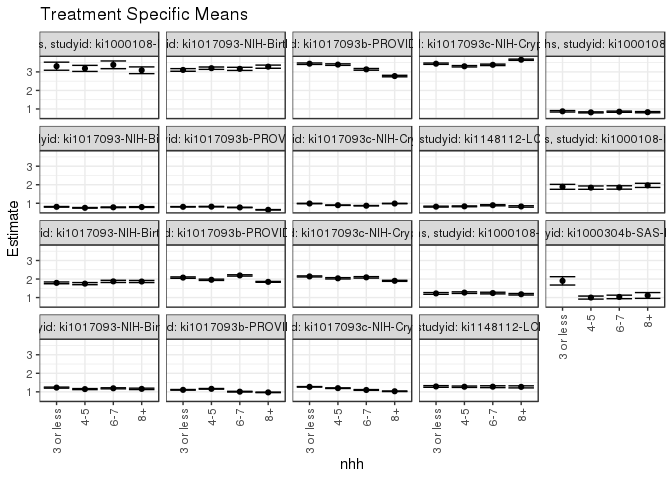

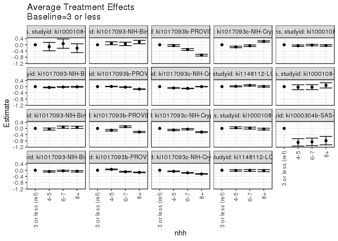

## Results Table

### Parameter: TSM

| agecat | studyid | country | intervention_level | baseline_level | estimate | ci_lower | ci_upper |
| --- | --- | --- | --- | --- | --- | --- | --- |
| 0-3 months | ki1000108-IRC | INDIA | 3 or less | NA | 3.3082425 | 3.0895090 | 3.5269761 |
| 0-3 months | ki1000108-IRC | INDIA | 4-5 | NA | 3.1895161 | 3.0253807 | 3.3536514 |
| 0-3 months | ki1000108-IRC | INDIA | 6-7 | NA | 3.3832572 | 3.1751821 | 3.5913323 |
| 0-3 months | ki1000108-IRC | INDIA | 8+ | NA | 3.0896488 | 2.9082409 | 3.2710566 |
| 0-3 months | ki1017093-NIH-Birth | BANGLADESH | 3 or less | NA | 3.1060826 | 3.0350405 | 3.1771247 |
| 0-3 months | ki1017093-NIH-Birth | BANGLADESH | 4-5 | NA | 3.2011969 | 3.1368161 | 3.2655777 |
| 0-3 months | ki1017093-NIH-Birth | BANGLADESH | 6-7 | NA | 3.1646527 | 3.0802939 | 3.2490115 |
| 0-3 months | ki1017093-NIH-Birth | BANGLADESH | 8+ | NA | 3.2825239 | 3.1962741 | 3.3687736 |
| 0-3 months | ki1017093b-PROVIDE | BANGLADESH | 3 or less | NA | 3.4433190 | 3.4036782 | 3.4829597 |
| 0-3 months | ki1017093b-PROVIDE | BANGLADESH | 4-5 | NA | 3.3949252 | 3.3532197 | 3.4366306 |
| 0-3 months | ki1017093b-PROVIDE | BANGLADESH | 6-7 | NA | 3.1375484 | 3.0924990 | 3.1825978 |
| 0-3 months | ki1017093b-PROVIDE | BANGLADESH | 8+ | NA | 2.7760828 | 2.7363670 | 2.8157985 |
| 0-3 months | ki1017093c-NIH-Crypto | BANGLADESH | 3 or less | NA | 3.4425957 | 3.4066654 | 3.4785260 |
| 0-3 months | ki1017093c-NIH-Crypto | BANGLADESH | 4-5 | NA | 3.3039961 | 3.2667913 | 3.3412009 |
| 0-3 months | ki1017093c-NIH-Crypto | BANGLADESH | 6-7 | NA | 3.3825798 | 3.3448492 | 3.4203105 |
| 0-3 months | ki1017093c-NIH-Crypto | BANGLADESH | 8+ | NA | 3.6570944 | 3.6245460 | 3.6896428 |
| 3-6 months | ki1000108-IRC | INDIA | 3 or less | NA | 1.8862021 | 1.7531226 | 2.0192815 |
| 3-6 months | ki1000108-IRC | INDIA | 4-5 | NA | 1.8432707 | 1.7536355 | 1.9329059 |
| 3-6 months | ki1000108-IRC | INDIA | 6-7 | NA | 1.8531278 | 1.7612761 | 1.9449795 |
| 3-6 months | ki1000108-IRC | INDIA | 8+ | NA | 1.9661670 | 1.8554219 | 2.0769122 |
| 3-6 months | ki1017093-NIH-Birth | BANGLADESH | 3 or less | NA | 1.7929081 | 1.7454713 | 1.8403450 |
| 3-6 months | ki1017093-NIH-Birth | BANGLADESH | 4-5 | NA | 1.7507204 | 1.6947341 | 1.8067067 |
| 3-6 months | ki1017093-NIH-Birth | BANGLADESH | 6-7 | NA | 1.8728809 | 1.8135921 | 1.9321696 |
| 3-6 months | ki1017093-NIH-Birth | BANGLADESH | 8+ | NA | 1.8649824 | 1.8077435 | 1.9222213 |
| 3-6 months | ki1017093b-PROVIDE | BANGLADESH | 3 or less | NA | 2.0770301 | 2.0413939 | 2.1126663 |
| 3-6 months | ki1017093b-PROVIDE | BANGLADESH | 4-5 | NA | 1.9588083 | 1.9242916 | 1.9933250 |
| 3-6 months | ki1017093b-PROVIDE | BANGLADESH | 6-7 | NA | 2.1931880 | 2.1575993 | 2.2287768 |
| 3-6 months | ki1017093b-PROVIDE | BANGLADESH | 8+ | NA | 1.8476688 | 1.8252807 | 1.8700569 |
| 3-6 months | ki1017093c-NIH-Crypto | BANGLADESH | 3 or less | NA | 2.1392974 | 2.1105211 | 2.1680737 |
| 3-6 months | ki1017093c-NIH-Crypto | BANGLADESH | 4-5 | NA | 2.0373901 | 2.0019122 | 2.0728680 |
| 3-6 months | ki1017093c-NIH-Crypto | BANGLADESH | 6-7 | NA | 2.0904193 | 2.0512342 | 2.1296044 |
| 3-6 months | ki1017093c-NIH-Crypto | BANGLADESH | 8+ | NA | 1.9023651 | 1.8748129 | 1.9299172 |
| 6-12 months | ki1000108-IRC | INDIA | 3 or less | NA | 1.2225843 | 1.1766311 | 1.2685375 |
| 6-12 months | ki1000108-IRC | INDIA | 4-5 | NA | 1.2667640 | 1.2243044 | 1.3092235 |
| 6-12 months | ki1000108-IRC | INDIA | 6-7 | NA | 1.2427258 | 1.1988332 | 1.2866183 |
| 6-12 months | ki1000108-IRC | INDIA | 8+ | NA | 1.1775916 | 1.1376779 | 1.2175052 |
| 6-12 months | ki1000304b-SAS-FoodSuppl | INDIA | 3 or less | NA | 1.9008566 | 1.6754951 | 2.1262180 |
| 6-12 months | ki1000304b-SAS-FoodSuppl | INDIA | 4-5 | NA | 0.9990311 | 0.9172800 | 1.0807823 |
| 6-12 months | ki1000304b-SAS-FoodSuppl | INDIA | 6-7 | NA | 1.0340856 | 0.9392420 | 1.1289292 |
| 6-12 months | ki1000304b-SAS-FoodSuppl | INDIA | 8+ | NA | 1.1128938 | 0.9571920 | 1.2685957 |
| 6-12 months | ki1017093-NIH-Birth | BANGLADESH | 3 or less | NA | 1.2285549 | 1.2003551 | 1.2567547 |
| 6-12 months | ki1017093-NIH-Birth | BANGLADESH | 4-5 | NA | 1.1479381 | 1.1197120 | 1.1761643 |
| 6-12 months | ki1017093-NIH-Birth | BANGLADESH | 6-7 | NA | 1.1916537 | 1.1626635 | 1.2206438 |
| 6-12 months | ki1017093-NIH-Birth | BANGLADESH | 8+ | NA | 1.1602857 | 1.1219074 | 1.1986639 |
| 6-12 months | ki1017093b-PROVIDE | BANGLADESH | 3 or less | NA | 1.1070770 | 1.0895393 | 1.1246148 |
| 6-12 months | ki1017093b-PROVIDE | BANGLADESH | 4-5 | NA | 1.1616828 | 1.1432807 | 1.1800850 |
| 6-12 months | ki1017093b-PROVIDE | BANGLADESH | 6-7 | NA | 1.0088504 | 0.9907969 | 1.0269039 |
| 6-12 months | ki1017093b-PROVIDE | BANGLADESH | 8+ | NA | 0.9703670 | 0.9563159 | 0.9844182 |
| 6-12 months | ki1017093c-NIH-Crypto | BANGLADESH | 3 or less | NA | 1.2701299 | 1.2551698 | 1.2850900 |
| 6-12 months | ki1017093c-NIH-Crypto | BANGLADESH | 4-5 | NA | 1.1981941 | 1.1798179 | 1.2165702 |
| 6-12 months | ki1017093c-NIH-Crypto | BANGLADESH | 6-7 | NA | 1.1009523 | 1.0793286 | 1.1225760 |
| 6-12 months | ki1017093c-NIH-Crypto | BANGLADESH | 8+ | NA | 1.0313609 | 1.0143159 | 1.0484058 |
| 6-12 months | ki1148112-LCNI-5 | MALAWI | 3 or less | NA | 1.2904674 | 1.2473146 | 1.3336202 |
| 6-12 months | ki1148112-LCNI-5 | MALAWI | 4-5 | NA | 1.2758623 | 1.2386377 | 1.3130868 |
| 6-12 months | ki1148112-LCNI-5 | MALAWI | 6-7 | NA | 1.2787118 | 1.2291886 | 1.3282349 |
| 6-12 months | ki1148112-LCNI-5 | MALAWI | 8+ | NA | 1.2682778 | 1.2129048 | 1.3236508 |
| 12-24 months | ki1000108-IRC | INDIA | 3 or less | NA | 0.8741692 | 0.8358601 | 0.9124783 |
| 12-24 months | ki1000108-IRC | INDIA | 4-5 | NA | 0.8168675 | 0.7898554 | 0.8438797 |
| 12-24 months | ki1000108-IRC | INDIA | 6-7 | NA | 0.8524541 | 0.8216620 | 0.8832462 |
| 12-24 months | ki1000108-IRC | INDIA | 8+ | NA | 0.8270281 | 0.7944034 | 0.8596527 |
| 12-24 months | ki1017093-NIH-Birth | BANGLADESH | 3 or less | NA | 0.8080042 | 0.7895580 | 0.8264504 |
| 12-24 months | ki1017093-NIH-Birth | BANGLADESH | 4-5 | NA | 0.7532201 | 0.7370963 | 0.7693439 |
| 12-24 months | ki1017093-NIH-Birth | BANGLADESH | 6-7 | NA | 0.7827206 | 0.7653153 | 0.8001259 |
| 12-24 months | ki1017093-NIH-Birth | BANGLADESH | 8+ | NA | 0.7955247 | 0.7751319 | 0.8159176 |
| 12-24 months | ki1017093b-PROVIDE | BANGLADESH | 3 or less | NA | 0.8087164 | 0.7966955 | 0.8207373 |
| 12-24 months | ki1017093b-PROVIDE | BANGLADESH | 4-5 | NA | 0.8174370 | 0.8043446 | 0.8305294 |
| 12-24 months | ki1017093b-PROVIDE | BANGLADESH | 6-7 | NA | 0.7736852 | 0.7621145 | 0.7852559 |
| 12-24 months | ki1017093b-PROVIDE | BANGLADESH | 8+ | NA | 0.6466617 | 0.6335711 | 0.6597522 |
| 12-24 months | ki1017093c-NIH-Crypto | BANGLADESH | 3 or less | NA | 0.9861433 | 0.9753531 | 0.9969334 |
| 12-24 months | ki1017093c-NIH-Crypto | BANGLADESH | 4-5 | NA | 0.8963369 | 0.8838801 | 0.9087937 |
| 12-24 months | ki1017093c-NIH-Crypto | BANGLADESH | 6-7 | NA | 0.8678290 | 0.8570624 | 0.8785955 |
| 12-24 months | ki1017093c-NIH-Crypto | BANGLADESH | 8+ | NA | 0.9861435 | 0.9759399 | 0.9963472 |
| 12-24 months | ki1148112-LCNI-5 | MALAWI | 3 or less | NA | 0.8173164 | 0.7923813 | 0.8422516 |
| 12-24 months | ki1148112-LCNI-5 | MALAWI | 4-5 | NA | 0.8343974 | 0.8102795 | 0.8585152 |
| 12-24 months | ki1148112-LCNI-5 | MALAWI | 6-7 | NA | 0.8945131 | 0.8634117 | 0.9256146 |
| 12-24 months | ki1148112-LCNI-5 | MALAWI | 8+ | NA | 0.8272345 | 0.7902048 | 0.8642642 |

### Parameter: E(Y)

| agecat | studyid | country | intervention_level | baseline_level | estimate | ci_lower | ci_upper |
| --- | --- | --- | --- | --- | --- | --- | --- |
| 0-3 months | ki1000108-IRC | INDIA | NA | NA | 3.1729204 | 3.0609523 | 3.2848884 |
| 0-3 months | ki1017093-NIH-Birth | BANGLADESH | NA | NA | 3.3129255 | 3.2581305 | 3.3677204 |
| 0-3 months | ki1017093b-PROVIDE | BANGLADESH | NA | NA | 3.4826706 | 3.4434873 | 3.5218539 |
| 0-3 months | ki1017093c-NIH-Crypto | BANGLADESH | NA | NA | 3.3028656 | 3.2646714 | 3.3410598 |
| 3-6 months | ki1000108-IRC | INDIA | NA | NA | 1.8806738 | 1.8168757 | 1.9444719 |
| 3-6 months | ki1017093-NIH-Birth | BANGLADESH | NA | NA | 1.8326915 | 1.7846731 | 1.8807099 |
| 3-6 months | ki1017093b-PROVIDE | BANGLADESH | NA | NA | 1.9654454 | 1.9303798 | 2.0005110 |
| 3-6 months | ki1017093c-NIH-Crypto | BANGLADESH | NA | NA | 2.0057973 | 1.9693775 | 2.0422170 |
| 6-12 months | ki1000108-IRC | INDIA | NA | NA | 1.2485668 | 1.2193308 | 1.2778028 |
| 6-12 months | ki1000304b-SAS-FoodSuppl | INDIA | NA | NA | 1.0131058 | 0.9370457 | 1.0891660 |
| 6-12 months | ki1017093-NIH-Birth | BANGLADESH | NA | NA | 1.1679344 | 1.1454934 | 1.1903754 |
| 6-12 months | ki1017093b-PROVIDE | BANGLADESH | NA | NA | 1.1731762 | 1.1558671 | 1.1904853 |
| 6-12 months | ki1017093c-NIH-Crypto | BANGLADESH | NA | NA | 1.2281313 | 1.2106849 | 1.2455776 |
| 6-12 months | ki1148112-LCNI-5 | MALAWI | NA | NA | 1.2790810 | 1.2528925 | 1.3052695 |
| 12-24 months | ki1000108-IRC | INDIA | NA | NA | 0.8294859 | 0.8099817 | 0.8489901 |
| 12-24 months | ki1017093-NIH-Birth | BANGLADESH | NA | NA | 0.7513013 | 0.7366996 | 0.7659029 |
| 12-24 months | ki1017093b-PROVIDE | BANGLADESH | NA | NA | 0.8575519 | 0.8455586 | 0.8695452 |
| 12-24 months | ki1017093c-NIH-Crypto | BANGLADESH | NA | NA | 0.8755729 | 0.8637860 | 0.8873598 |
| 12-24 months | ki1148112-LCNI-5 | MALAWI | NA | NA | 0.8407809 | 0.8238743 | 0.8576875 |

### Parameter: ATE

| agecat | studyid | country | intervention_level | baseline_level | estimate | ci_lower | ci_upper |
| --- | --- | --- | --- | --- | --- | --- | --- |
| 0-3 months | ki1000108-IRC | INDIA | 3 or less | 3 or less | 0.0000000 | 0.0000000 | 0.0000000 |
| 0-3 months | ki1000108-IRC | INDIA | 4-5 | 3 or less | -0.1187265 | -0.3911626 | 0.1537096 |
| 0-3 months | ki1000108-IRC | INDIA | 6-7 | 3 or less | 0.0750147 | -0.2252908 | 0.3753201 |
| 0-3 months | ki1000108-IRC | INDIA | 8+ | 3 or less | -0.2185938 | -0.5026803 | 0.0654927 |
| 0-3 months | ki1017093-NIH-Birth | BANGLADESH | 3 or less | 3 or less | 0.0000000 | 0.0000000 | 0.0000000 |
| 0-3 months | ki1017093-NIH-Birth | BANGLADESH | 4-5 | 3 or less | 0.0951143 | -0.0003979 | 0.1906264 |
| 0-3 months | ki1017093-NIH-Birth | BANGLADESH | 6-7 | 3 or less | 0.0585701 | -0.0516248 | 0.1687650 |
| 0-3 months | ki1017093-NIH-Birth | BANGLADESH | 8+ | 3 or less | 0.1764412 | 0.0650478 | 0.2878347 |
| 0-3 months | ki1017093b-PROVIDE | BANGLADESH | 3 or less | 3 or less | 0.0000000 | 0.0000000 | 0.0000000 |
| 0-3 months | ki1017093b-PROVIDE | BANGLADESH | 4-5 | 3 or less | -0.0483938 | -0.1056758 | 0.0088882 |
| 0-3 months | ki1017093b-PROVIDE | BANGLADESH | 6-7 | 3 or less | -0.3057706 | -0.3665841 | -0.2449571 |
| 0-3 months | ki1017093b-PROVIDE | BANGLADESH | 8+ | 3 or less | -0.6672362 | -0.7249390 | -0.6095334 |
| 0-3 months | ki1017093c-NIH-Crypto | BANGLADESH | 3 or less | 3 or less | 0.0000000 | 0.0000000 | 0.0000000 |
| 0-3 months | ki1017093c-NIH-Crypto | BANGLADESH | 4-5 | 3 or less | -0.1385996 | -0.1860796 | -0.0911196 |
| 0-3 months | ki1017093c-NIH-Crypto | BANGLADESH | 6-7 | 3 or less | -0.0600159 | -0.1097187 | -0.0103131 |
| 0-3 months | ki1017093c-NIH-Crypto | BANGLADESH | 8+ | 3 or less | 0.2144987 | 0.1674362 | 0.2615612 |
| 3-6 months | ki1000108-IRC | INDIA | 3 or less | 3 or less | 0.0000000 | 0.0000000 | 0.0000000 |
| 3-6 months | ki1000108-IRC | INDIA | 4-5 | 3 or less | -0.0429314 | -0.2019672 | 0.1161045 |
| 3-6 months | ki1000108-IRC | INDIA | 6-7 | 3 or less | -0.0330743 | -0.1934219 | 0.1272733 |
| 3-6 months | ki1000108-IRC | INDIA | 8+ | 3 or less | 0.0799650 | -0.0905876 | 0.2505176 |
| 3-6 months | ki1017093-NIH-Birth | BANGLADESH | 3 or less | 3 or less | 0.0000000 | 0.0000000 | 0.0000000 |
| 3-6 months | ki1017093-NIH-Birth | BANGLADESH | 4-5 | 3 or less | -0.0421877 | -0.1101526 | 0.0257772 |
| 3-6 months | ki1017093-NIH-Birth | BANGLADESH | 6-7 | 3 or less | 0.0799727 | 0.0094756 | 0.1504699 |
| 3-6 months | ki1017093-NIH-Birth | BANGLADESH | 8+ | 3 or less | 0.0720743 | 0.0024674 | 0.1416811 |
| 3-6 months | ki1017093b-PROVIDE | BANGLADESH | 3 or less | 3 or less | 0.0000000 | 0.0000000 | 0.0000000 |
| 3-6 months | ki1017093b-PROVIDE | BANGLADESH | 4-5 | 3 or less | -0.1182218 | -0.1675607 | -0.0688829 |
| 3-6 months | ki1017093b-PROVIDE | BANGLADESH | 6-7 | 3 or less | 0.1161579 | 0.0653802 | 0.1669357 |
| 3-6 months | ki1017093b-PROVIDE | BANGLADESH | 8+ | 3 or less | -0.2293613 | -0.2708589 | -0.1878637 |
| 3-6 months | ki1017093c-NIH-Crypto | BANGLADESH | 3 or less | 3 or less | 0.0000000 | 0.0000000 | 0.0000000 |
| 3-6 months | ki1017093c-NIH-Crypto | BANGLADESH | 4-5 | 3 or less | -0.1019073 | -0.1430175 | -0.0607971 |
| 3-6 months | ki1017093c-NIH-Crypto | BANGLADESH | 6-7 | 3 or less | -0.0488781 | -0.0927982 | -0.0049580 |
| 3-6 months | ki1017093c-NIH-Crypto | BANGLADESH | 8+ | 3 or less | -0.2369323 | -0.2729495 | -0.2009152 |
| 6-12 months | ki1000108-IRC | INDIA | 3 or less | 3 or less | 0.0000000 | 0.0000000 | 0.0000000 |
| 6-12 months | ki1000108-IRC | INDIA | 4-5 | 3 or less | 0.0441797 | -0.0172299 | 0.1055892 |
| 6-12 months | ki1000108-IRC | INDIA | 6-7 | 3 or less | 0.0201414 | -0.0424839 | 0.0827668 |
| 6-12 months | ki1000108-IRC | INDIA | 8+ | 3 or less | -0.0449927 | -0.1039357 | 0.0139502 |
| 6-12 months | ki1000304b-SAS-FoodSuppl | INDIA | 3 or less | 3 or less | 0.0000000 | 0.0000000 | 0.0000000 |
| 6-12 months | ki1000304b-SAS-FoodSuppl | INDIA | 4-5 | 3 or less | -0.9018254 | -1.1377004 | -0.6659505 |
| 6-12 months | ki1000304b-SAS-FoodSuppl | INDIA | 6-7 | 3 or less | -0.8667710 | -1.1064020 | -0.6271400 |
| 6-12 months | ki1000304b-SAS-FoodSuppl | INDIA | 8+ | 3 or less | -0.7879628 | -1.0605700 | -0.5153555 |
| 6-12 months | ki1017093-NIH-Birth | BANGLADESH | 3 or less | 3 or less | 0.0000000 | 0.0000000 | 0.0000000 |
| 6-12 months | ki1017093-NIH-Birth | BANGLADESH | 4-5 | 3 or less | -0.0806168 | -0.1204259 | -0.0408076 |
| 6-12 months | ki1017093-NIH-Birth | BANGLADESH | 6-7 | 3 or less | -0.0369012 | -0.0774195 | 0.0036171 |
| 6-12 months | ki1017093-NIH-Birth | BANGLADESH | 8+ | 3 or less | -0.0682692 | -0.1159898 | -0.0205486 |
| 6-12 months | ki1017093b-PROVIDE | BANGLADESH | 3 or less | 3 or less | 0.0000000 | 0.0000000 | 0.0000000 |
| 6-12 months | ki1017093b-PROVIDE | BANGLADESH | 4-5 | 3 or less | 0.0546058 | 0.0293254 | 0.0798862 |
| 6-12 months | ki1017093b-PROVIDE | BANGLADESH | 6-7 | 3 or less | -0.0982266 | -0.1238609 | -0.0725924 |
| 6-12 months | ki1017093b-PROVIDE | BANGLADESH | 8+ | 3 or less | -0.1367100 | -0.1599772 | -0.1134428 |
| 6-12 months | ki1017093c-NIH-Crypto | BANGLADESH | 3 or less | 3 or less | 0.0000000 | 0.0000000 | 0.0000000 |
| 6-12 months | ki1017093c-NIH-Crypto | BANGLADESH | 4-5 | 3 or less | -0.0719358 | -0.0954405 | -0.0484311 |
| 6-12 months | ki1017093c-NIH-Crypto | BANGLADESH | 6-7 | 3 or less | -0.1691776 | -0.1953473 | -0.1430079 |
| 6-12 months | ki1017093c-NIH-Crypto | BANGLADESH | 8+ | 3 or less | -0.2387690 | -0.2616333 | -0.2159047 |
| 6-12 months | ki1148112-LCNI-5 | MALAWI | 3 or less | 3 or less | 0.0000000 | 0.0000000 | 0.0000000 |
| 6-12 months | ki1148112-LCNI-5 | MALAWI | 4-5 | 3 or less | -0.0146052 | -0.0677925 | 0.0385822 |
| 6-12 months | ki1148112-LCNI-5 | MALAWI | 6-7 | 3 or less | -0.0117557 | -0.0747609 | 0.0512496 |
| 6-12 months | ki1148112-LCNI-5 | MALAWI | 8+ | 3 or less | -0.0221896 | -0.0902890 | 0.0459098 |
| 12-24 months | ki1000108-IRC | INDIA | 3 or less | 3 or less | 0.0000000 | 0.0000000 | 0.0000000 |
| 12-24 months | ki1000108-IRC | INDIA | 4-5 | 3 or less | -0.0573017 | -0.1036469 | -0.0109565 |
| 12-24 months | ki1000108-IRC | INDIA | 6-7 | 3 or less | -0.0217151 | -0.0705702 | 0.0271401 |
| 12-24 months | ki1000108-IRC | INDIA | 8+ | 3 or less | -0.0471411 | -0.0969153 | 0.0026330 |
| 12-24 months | ki1017093-NIH-Birth | BANGLADESH | 3 or less | 3 or less | 0.0000000 | 0.0000000 | 0.0000000 |
| 12-24 months | ki1017093-NIH-Birth | BANGLADESH | 4-5 | 3 or less | -0.0547841 | -0.0769767 | -0.0325915 |
| 12-24 months | ki1017093-NIH-Birth | BANGLADESH | 6-7 | 3 or less | -0.0252836 | -0.0484580 | -0.0021092 |
| 12-24 months | ki1017093-NIH-Birth | BANGLADESH | 8+ | 3 or less | -0.0124795 | -0.0379624 | 0.0130034 |
| 12-24 months | ki1017093b-PROVIDE | BANGLADESH | 3 or less | 3 or less | 0.0000000 | 0.0000000 | 0.0000000 |
| 12-24 months | ki1017093b-PROVIDE | BANGLADESH | 4-5 | 3 or less | 0.0087206 | -0.0087620 | 0.0262032 |
| 12-24 months | ki1017093b-PROVIDE | BANGLADESH | 6-7 | 3 or less | -0.0350312 | -0.0523520 | -0.0177103 |
| 12-24 months | ki1017093b-PROVIDE | BANGLADESH | 8+ | 3 or less | -0.1620547 | -0.1808277 | -0.1432818 |
| 12-24 months | ki1017093c-NIH-Crypto | BANGLADESH | 3 or less | 3 or less | 0.0000000 | 0.0000000 | 0.0000000 |
| 12-24 months | ki1017093c-NIH-Crypto | BANGLADESH | 4-5 | 3 or less | -0.0898064 | -0.1063207 | -0.0732921 |
| 12-24 months | ki1017093c-NIH-Crypto | BANGLADESH | 6-7 | 3 or less | -0.1183143 | -0.1335323 | -0.1030964 |
| 12-24 months | ki1017093c-NIH-Crypto | BANGLADESH | 8+ | 3 or less | 0.0000003 | -0.0157351 | 0.0157357 |
| 12-24 months | ki1148112-LCNI-5 | MALAWI | 3 or less | 3 or less | 0.0000000 | 0.0000000 | 0.0000000 |
| 12-24 months | ki1148112-LCNI-5 | MALAWI | 4-5 | 3 or less | 0.0170809 | -0.0175946 | 0.0517564 |
| 12-24 months | ki1148112-LCNI-5 | MALAWI | 6-7 | 3 or less | 0.0771967 | 0.0373607 | 0.1170327 |
| 12-24 months | ki1148112-LCNI-5 | MALAWI | 8+ | 3 or less | 0.0099180 | -0.0347414 | 0.0545774 |